# Multiple Comparisons Procedures

## Distribution of *P* values

*P* values resulting from chance alone have a uniform distribution

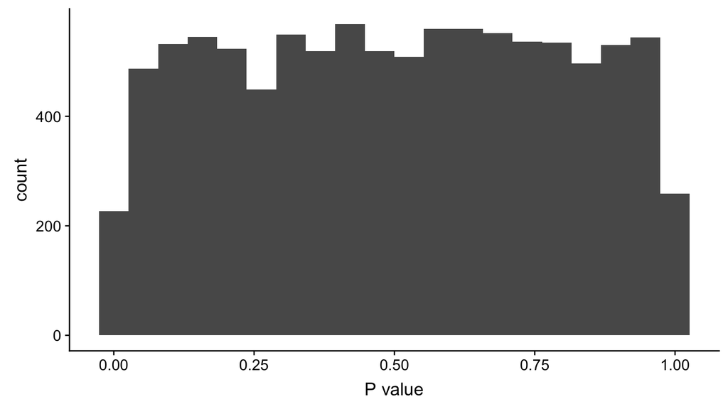

## Distribution of *P* values

*P* values resulting from chance alone have a uniform distribution

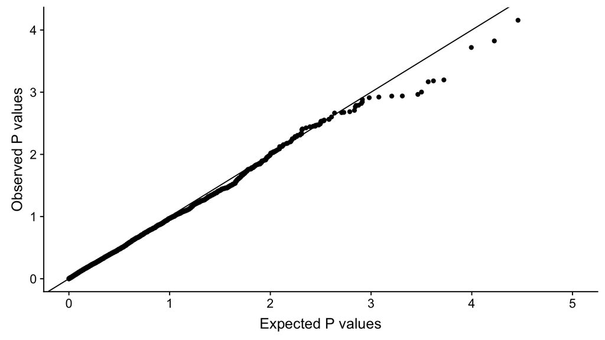

## Distribution of *P* values

*P* values resulting from chance alone have a uniform distribution

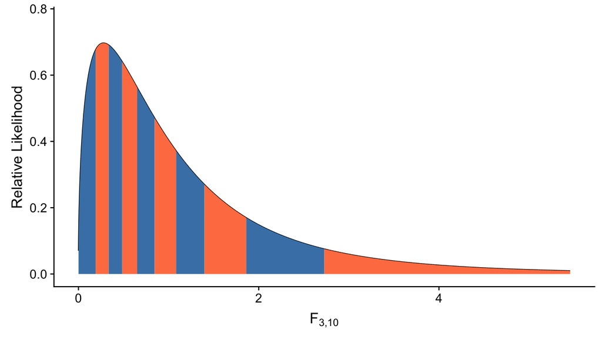

## Example *P* values to work with

### Turning kinematics in hummingbirds

```r
Ps <- read_excel("../data/P_values.xlsx")
glimpse(Ps)
```

```
## Observations: 203
## Variables: 1
## $ P <dbl> 6.984504e-02, 2.141840e-05, 1.624760e-01, 1.450266e-02, 6.3557…
```

```r
range(Ps$P)
```

```
## [1] 1.000000e-16 9.916772e-01
```

203 *P* values. Range: 10<sup>-16</sup> to 0.992

## A menu of MCPs

1. Do nothing
   - Not an option
2. Common sense
3. Bonferroni correction
4. Sequential Bonferroni procedure
5. Permutation Test
6. False Discovery Rate
7. *Positive* False Discovery Rate

## “Common sense”

\(203 \times 0.05 = 10.15\) expected significant results.

```r
sum(Ps$P < 0.05)
```

```
## [1] 62
```

We have 62. So maybe only consider the smallest 10?

- Extremely conservative

This is also subjective (which *P* values to trust?). We can do better.

## A menu of MCPs

1. Do nothing
2. Common sense
   - As of this slide you know better, if you did not already
3. Bonferroni correction
4. Sequential Bonferroni procedure
5. False Discovery Rate
6. *Positive* False Discovery Rate

## History

Statisticians have known of the problem for a long time:

- Can be traced back to Galton (1902) and Pearson (1902), who were interested in rare occurrences
  - How to fairly divide a prizes in a competition

Not a huge leap to go from single observations as outliers to families of tests

- Student (1927) discusses sources of error, including variation in repeated analyses. Introduced the use of a range as a criterion
- Working and Hotelling (1929) developed confidence intervals for linear regression

## History

Examples in which investigators tried to deal with it can be found scattered throughout the literature.

- Fisher (1935): sequential *t*-tests following a significant ANOVA (later developed into least significant difference test)
- Newman (1939): studentized range test for ANOVA-like analyses

## History

Duncan, Scheffé, and Tukey were responsible for the true modernization of multiple comparison procedures.

- Duncan (1947, 1951, 1955, 1957): a variety of “multiple range tests”
- Tukey (1949): most responsible for getting MCPs into much more general use (honestly significantly differences)
- Scheffé (1953): connected multiple comparisons procedures to general linear hypothesis tests. Method for comparing all contrasts in an ANOVA.

## Modern history

The widespread emergence of RNA microarrays and “gene chips” (which can involve >10,000 simultaneous comparisons) as well as “genomic data” more broadly (sequential tests of 10<sup>5</sup>-10<sup>7</sup> SNPs) focused biostatisticians on the problem.

- Storey and Tibshirani (2003)
- van der Laan et al. (2004)
- Dudoit and van der Laan (2008)

## Goals of multiple comparisons procedures

Type I and Type II errors will trade-off.

## General procedure

1. Complete an entire “family” of tests
   - A set of tests on related data
   - A single publication
   - A single thesis
   - All of science?
2. Collect the resulting *P* values into a single vector or `data.frame`.
3. Perform a multiple comparisons procedure (directly adjust or calculate new \(\alpha\) level)
4. Assess significance of your tests *as a whole*

## Bonferroni correction

- Dates to Fisher (1935)
- Define an adjusted alpha level of \(\alpha/k\) where \(k\) is the number of tests. Use that adjusted \(\alpha_{adj}\) to decide if a test is statistically significant.
- Simplest and most conservative method
  - Relies on the Bonferroni inequality and results in control of FWER at \(\alpha\)
- Can result in excessive false negatives (i.e., too many Type II errors)

\[\alpha_{adj} = \frac{\alpha}{k}\]

## Distribution of *P* values

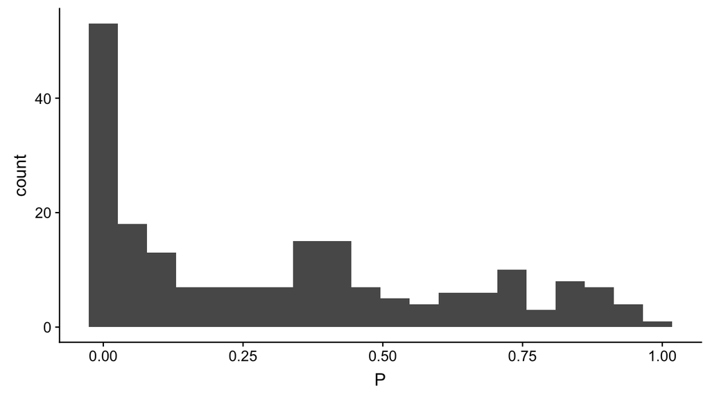

We have disproportionately more nominally significant tests. Otherwise relatively uniform.

## Distribution of *P* values

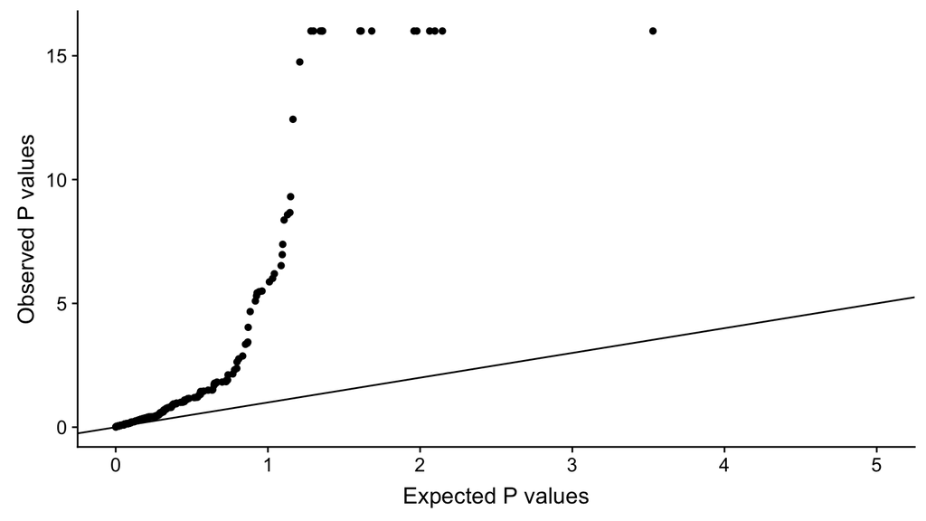

## Sort *P* values

It will be easier to follow the procedures if the rows are sorted smallest to largest:

```r
Ps <- Ps %>% arrange(P)
head(Ps)
```

```
## # A tibble: 6 x 1
##          P
##      <dbl>
## 1 1.00e-16
## 2 1.00e-16
## 3 1.00e-16
## 4 1.00e-16
## 5 1.00e-16
## 6 1.00e-16
```

## Bonferroni correction

Adjusted \(\alpha\) level for significance is \(\alpha / k\):

```r
(alpha_adj <- 0.05 / nrow(Ps))
```

```
## [1] 0.0002463054
```

Judging any *P* values < 0.00024 as significant will control the FWER at \(\alpha = 0.05\).

## Bonferroni correction

```r
Ps$Bonf <- Ps$P < alpha_adj
sum(Ps$Bonf)
```

```
## [1] 33
```

Only 33 of the original 62 significant test remain significant.

## Bonferroni correction

```r
Ps %>% slice(30:37)
```

```
## # A tibble: 8 x 2
##            P Bonf
##        <dbl> <lgl>
## 1 0.00000498 TRUE
## 2 0.00000800 TRUE
## 3 0.0000214  TRUE
## 4 0.0000928  TRUE
## 5 0.000365   FALSE
## 6 0.000390   FALSE
## 7 0.000407   FALSE
## 8 0.000448   FALSE
```

## A menu of MCPs

1. Do nothing
2. Common sense
3. Bonferroni correction
   - Excessively conservative, and we can do better
4. Sequential Bonferroni procedure
5. False Discovery Rate
6. *Positive* False Discovery Rate

## Sequential Bonferroni

Controls FWER as well as Bonferroni but is more permissive

- Introduced by Holm (1979) - “Holm procedure”
- Also see Rice (1989) for discussion

All the methods from here on rely on a sorted list of *P* values.

## Sequential Bonferroni

- Sort the *P* values from smallest (\(p_1\)) to largest (\(p_k\))
- Start with the smallest (\(i = 1\)), and evaluate the inequality:

\[p_i \leq \frac{\alpha}{k - i + 1}\]

- If the inequality is *true*, call that test significant
- No difference from the the Bonferroni correction yet.
  - Step 1 equals Bonferroni correction

## Sequential Bonferroni

- Repeat for \(i = 2, 3, 4, \dots\), up to \(i = k\).
- At each step, the test value increases:

```r
0.05 / 203
```

```
## [1] 0.0002463054
```

```r
0.05 / 202
```

```
## [1] 0.0002475248
```

The last observed *P* value is compared to \(\alpha\).

## Sequential Bonferroni

If the inequality is *ever* false:

- Stop.
- Fail to reject that test.
- Fail to reject all remaining tests (because the list is sorted)

## R’s `p.adjust()` function

`p.adjust()` can do some multiple comparisons procedures, given a vector of *P*.

```r
Ps$Bonf <- p.adjust(Ps$P, "bonferroni") < 0.05 # Bonferroni
Ps$Seq_Bonf <- p.adjust(Ps$P, "holm") < 0.05   # Sequential Bonferroni
sum(Ps$Seq_Bonf)
```

```
## [1] 33
```

Only 33 of the original 62 significant tests remain.

## Sequential Bonferroni

```r
Ps %>% slice(30:37)
```

```
## # A tibble: 8 x 3
##            P Bonf  Seq_Bonf
##        <dbl> <lgl> <lgl>
## 1 0.00000498 TRUE  TRUE
## 2 0.00000800 TRUE  TRUE
## 3 0.0000214  TRUE  TRUE
## 4 0.0000928  TRUE  TRUE
## 5 0.000365   FALSE FALSE
## 6 0.000390   FALSE FALSE
## 7 0.000407   FALSE FALSE
## 8 0.000448   FALSE FALSE
```

Here, Bonferroni and sequential Bonferroni are equal.

## Permutation Test: Randomization to the Rescue

Procedure:

- Shuffle the data
- Perform your set of tests
- Get the lowest p-value across all tests
- Repeat many, many times
- Calculate the threshold for which there is a 5% chance of observing one false positive across all tests (FWER)

## A menu of MCPs

1. Do nothing
   - Not an option
2. Common sense
3. Bonferroni correction
4. Sequential Bonferroni procedure
5. Permutation Test
6. False Discovery Rate
7. *Positive* False Discovery Rate

## Quiz 12-2

Lecture 12-3

## References

Dudoit, S., and M. J. van der Laan. 2008. *Multiple Testing Procedures with Applications to Genomics*. Springer, New York.

Duncan, D. B. 1951. *A Significance Test for Differences Between Ranked Treatments in an Analysis of Variance*. Virginia Polytechnic Institute.

Duncan, D. B. 1955. Multiple Range and Multiple F Tests. *Biometrics* 11:1–42. [Wiley, International Biometric Society].

Duncan, D. B. 1957. Multiple Range Tests for Correlated and Heteroscedastic Means. *Biometrics* 13:164–176. [Wiley, International Biometric Society].

Duncan, D. B. 1947. Significance Tests for Differences Between Ranked Variates Drawn from Normal Populations. Iowa State College, Ames, IA.

Fisher, R. A. 1935. *The Design of Experiments*. Oliver & Boyd, Edinburgh; London.

Galton, F. 1902. The Most Suitable Proportion Between the Value of First and Second Prizes. *Biometrika* 1:385–399. [Oxford University Press, Biometrika Trust].

Holm, S. 1979. A Simple Sequentially Rejective Multiple Test Procedure. *Scandinavian Journal of Statistics, Theory and Applications* 6:65–70. [Board of the Foundation of the Scandinavian Journal of Statistics, Wiley].

Laan, M. J. van der, S. Dudoit, and K. S. Pollard. 2004. Augmentation Procedures for Control of the Generalized Family-Wise Error Rate and Tail Probabilities for the Proportion of False Positives. *Statistical Applications in Genetics and Molecular Biology* 3:Article15.

Newman, D. 1939. The Distribution of Range in Samples from a Normal Population, Expressed in Terms of an Independent Estimate of Standard Deviation. *Biometrika* 31:20–30. [Oxford University Press, Biometrika Trust].

Pearson, K. 1902. Note on Francis Galton’s Problem. *Biometrika* 1:390–399.

Rice, W. R. 1989. Analyzing Tables of Statistical Tests. *Evolution* 43:223–225. [Society for the Study of Evolution, Wiley].

Scheffé, H. 1953. A Method for Judging All Contrasts in the Analysis of Variance. *Biometrika* 40:87–104. [Oxford University Press, Biometrika Trust].

Storey, J. D., and R. Tibshirani. 2003. Statistical Significance for Genomewide Studies. *Proceedings of the National Academy of Sciences of the United States of America* 100:9440–9445.

Student. 1927. Errors of Routine Analysis. *Biometrika* 19:151–164. [Oxford University Press, Biometrika Trust].

Tukey, J. W. 1949. Comparing Individual Means in the Analysis of Variance. *Biometrics* 5:99–114.

Working, H., and H. Hotelling. 1929. Applications of the Theory of Error to the Interpretation of Trends. *Journal of the American Statistical Association* 24:73–85. [American Statistical Association, Taylor & Francis, Ltd.].